# 该数据集来自2019年Airbnb在纽约的公开数据

# **- 可能会影响Airbnb上房屋的出租的几个因素**

- 五大区治安角度问题，Manhattan>Queen≈Brooklyn≈>Bronx
- 全年可租天数
- 受欢迎程度（由总评论数体现）
- 价格
- 整租还是合租
- 其中价格和受欢迎程度为因变量

```python
import numpy as np
import pandas as pd
import matplotlib.pyplot as plt
import math
plt.style.use("ggplot")
import seaborn as sns
%matplotlib inline
```

```python
data = pd.read_csv('AB_NYC_2019.csv')
df = data.copy()
```

```python
data.isnull().sum()
```

```
id                                    0
name                                 16
host_id                               0
host_name                            21
neighbourhood_group                   0
neighbourhood                         0
latitude                              0
longitude                             0
room_type                             0
price                                 0
minimum_nights                        0
number_of_reviews                     0
last_review                       10052
reviews_per_month                 10052
calculated_host_listings_count        0
availability_365                      0
dtype: int64
```

```python
i = df.loc[df["price"] == 0].index                #极少数价格为0，明显不符合实际，删去
df.drop(i,inplace = True)
```

**先探寻各因素之前存在的关系**

**五大区和房屋类型对房屋价格和欢迎程度的影响**

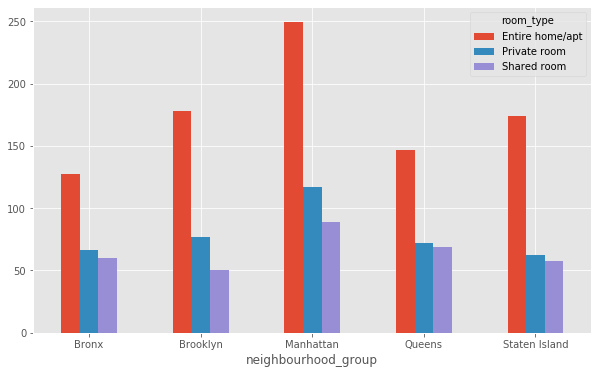

```python
d1 = df.pivot_table(index = 'neighbourhood_group',columns = 'room_type', values = 'price', aggfunc = 'mean')
d1.plot.bar(figsize = (10,6), rot=0)
plt.show()
```

五个区都是Entire Home的价格大于Private room大于Shared room，符合常理，整租的一般要比合租的贵，且曼哈顿的价格明显高于其他区，也侧面反映出了曼哈顿在纽约的繁华，而Bronx的各类租金较低，可能也与和其他地方对比起来较差的治安有关。

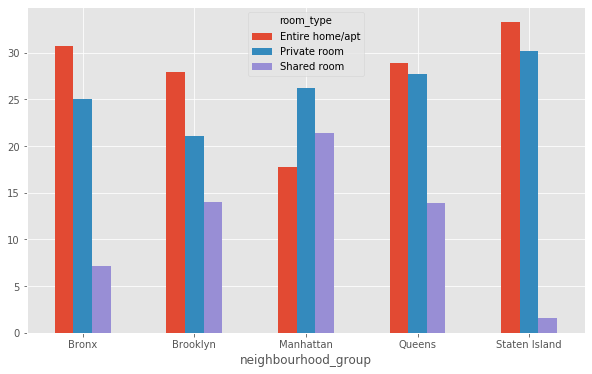

```python
d2 = df.pivot_table(index = 'neighbourhood_group',columns = 'room_type', values = 'number_of_reviews', aggfunc = 'mean')
d2.plot.bar(figsize = (10,6), rot=0)
plt.show()
```

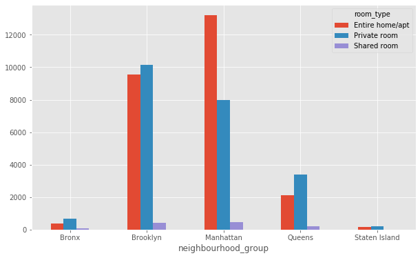

```python
d2 = df.pivot_table(index = 'neighbourhood_group', columns = 'room_type',values = 'id', aggfunc = 'count')
d2.plot.bar(figsize = (10,6), rot=0)
plt.show()
```

由图可以看出，绝大多数房屋分布在曼哈顿和布鲁克林，除了曼哈顿，都是整房或整屋比合租远比受欢迎，而曼哈顿则反过来（整屋大于合租大于整房），猜测可能是由于曼哈顿的租金过于昂贵（尤其是整房），使得人们更加倾向于选择性价比高的房屋。

**观察最短可租时间和全年可租时间对价格和欢迎程度的影响**

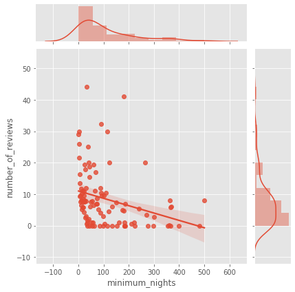

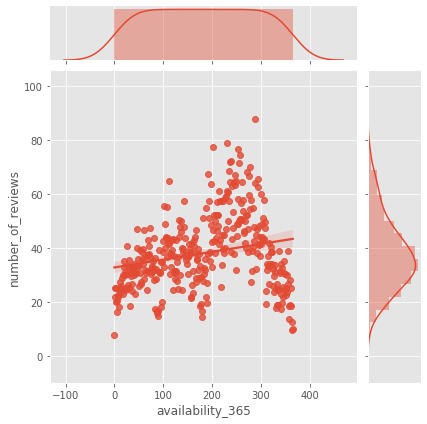

```python
bbb = df.groupby("minimum_nights").mean().reset_index()
g = sns.jointplot(x="minimum_nights", y="number_of_reviews", data = bbb.query("minimum_nights < 600 & number_of_reviews < 60"),kind= "reg" )
ccc = df.groupby("availability_365").mean().reset_index()
sns.jointplot(x="availability_365", y="number_of_reviews", data = ccc.query("number_of_reviews < 10000"),kind= "reg" )
plt.show()
```

在去除极值后，上图反映出在2019年，随着最短可租天数的增加,评论数降低；全年可租天数的增加，评论数上涨。 反映了纽约地区选择Airbnb的人群偏好最小可租天数短，全年可租天数长的房子

接下来分析价格与受欢迎程度的关系

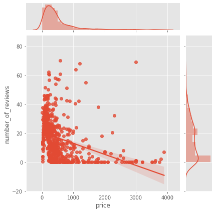

```python
aaa = df.groupby("price").mean().reset_index()

#aaa.query("price < 4000").plot.scatter(x="price",y="number_of_reviews")
sns.jointplot(x="price", y="number_of_reviews", data = aaa.query("number_of_reviews < 75 & price < 4000"),kind= "reg" )
plt.show()
```

上图中随着价格的升高，评论数呈下降趋势，且Airbnb的人群的消费区间大多在1000元以下。

# **计算房屋质量分数（即性价比）**

采用指数法（地区0.2，房屋类型0.2，价格高0.2，评论数0.2，最短可租天数和全年可租天数均0.1）,其中价格和评论数用log收敛

```python
place = {'Manhattan': 3, "Queens":2,"Staten Island":2,"Brooklyn":2,"Bronx":1}
place["Staten Island"]

Type = {"Entire home/apt": 3, "Private room": 2,"Shared room": 0.5}
```

```python
df["s"] = 0
```

```python
def fun(x):
    s1 = place[x.neighbourhood_group]
    s2 = math.log(x.price, 10000)
    s3 = Type[x.room_type]
    if x.availability_365 > 365:
        s4 = 1
    else:
        s4 = x.availability_365 / 365
    if x.minimum_nights > 365:
        s5 = 0
    else:
        s5 = (365 - x.minimum_nights) / 365
    if x.number_of_reviews == 0:
        s6 = 0
    else:
        s6 = math.log(x.number_of_reviews, 629)
    return s2 * 0.2+ s1 / 3 * 0.2 + s3 / 3 * 0.2 + s4*0.1 + s5*0.1 + s6 * 0.2
rr = df.apply(fun,axis=1)
df.s = rr
```

```python
df.s.quantile(0.01)
```

```
0.4271165228003188
```

质量分数能超过总体百分之90的即为高质量，低于百分之10的即为低质量

```python
high_quality_house = df.loc[(df["calculated_host_listings_count"] > 10) & (df["s"] > df.s.quantile(0.9))]

low_quality_house = df.loc[(df["calculated_host_listings_count"] > 10) & (df["s"] < df.s.quantile(0.1))]

landlord_of_high_quality_house = high_quality_house.groupby("host_id").mean().sort_values("s",ascending = False)
landlord_of_low_quality_house = low_quality_house.groupby("host_id").mean().sort_values("s")
```

```python
lame = landlord_of_low_quality_house.reset_index().host_id.reset_index().drop("index",axis= 1)
good = landlord_of_high_quality_house.reset_index().host_id.reset_index().drop("index",axis= 1)
good.rename(columns={"host_id": "High_quality_host_id"},inplace = True)
lame.rename(columns={'host_id': 'Low_quality_host_id'}, inplace = True)
```

```python
result = pd.concat([good, lame], axis=1, sort=False)
result.T
```

|  | 0 | 1 | 2 | 3 | 4 | 5 | 6 | 7 | 8 | 9 | ... | 30 | 31 | 32 | 33 | 34 | 35 | 36 | 37 | 38 | 39 |
| --- | --- | --- | --- | --- | --- | --- | --- | --- | --- | --- | --- | --- | --- | --- | --- | --- | --- | --- | --- | --- | --- |
| High_quality_host_id | 836168.0 | 164886138.0 | 64065593.0 | 35524316.0 | 16677326.0 | 211549023.0 | 219517861.0 | 39890192.0 | 2119276.0 | 3191545.0 | ... | 13347167.0 | 52950465.0 | 177174475.0 | 100238132.0 | 9864136.0 | 45595980.0 | 10457196.0 | 224414117.0 | 137274917.0 | 12243051.0 |
| Low_quality_host_id | 51596474.0 | 310670.0 | 204852306.0 | 3250450.0 | 248161322.0 | 213781715.0 | 226410657.0 | 19303369.0 | 201015598.0 | 175730239.0 | ... | NaN | NaN | NaN | NaN | NaN | NaN | NaN | NaN | NaN | NaN |

2 rows × 40 columns

上表显示出了高质量的房东与低质量房东的id，平台应该有针对性的**维护高质量房东，为他们提供佣金折扣以及各种福利待遇**；也能够**惩罚低质量房东，督促房东改进房源，提升平台的整理质量。**

- **计算五大区内各郡所拥有高质量房屋的数量，筛选出各区的前3**

```python
temp = df.loc[(df["s"] > df.s.quantile(0.9))].groupby(['neighbourhood_group', 'neighbourhood']).count()
g = temp.reset_index()
```

```python
a = g[["neighbourhood_group", "neighbourhood", "id"]].rename(columns = {"id": "count"})
```

```python
def funnn(x):
    r = x.sort_values('count', ascending=False)
    return r[["neighbourhood", "count"]][:3]
z = a.groupby("neighbourhood_group").apply(funnn)
z
```

| neighbourhood_group |  | neighbourhood | count |
| --- | --- | --- | --- |
| Bronx | 0 | Allerton | 1 |
| Brooklyn | 3 | Bedford-Stuyvesant | 262 |
|  | 40 | Williamsburg | 138 |
|  | 17 | Crown Heights | 79 |
| Manhattan | 52 | Harlem | 420 |
|  | 53 | Hell's Kitchen | 379 |
|  | 70 | Upper East Side | 311 |
| Queens | 75 | Astoria | 32 |
|  | 94 | Long Island City | 20 |
|  | 84 | East Elmhurst | 17 |
| Staten Island | 113 | Clifton | 5 |
|  | 121 | St. George | 4 |
|  | 123 | Tompkinsville | 3 |

- **上表显示了五大区内各郡拥有高质量房屋最多的前3**
- 其中Bronx只有一个Allerton拥有高质量房屋，也侧面体现出该区的发达程度不如其他四个区
- 大量高质量房屋则出现在Brooklyn和Manhattan

# 小结

1. **房屋现状与用户需求总结**
   - 房屋大多分布在曼哈顿和布鲁克林两个区
   - 除了曼哈顿，其余四个区都是Private room的数量多于Entire home/apt（Shared room在哪里都即为稀少），租金自然是Entire home/apt>Private room>Shared room
   - 但曼哈顿的整体的房屋租金要显著高于另外四个区，其余的差距不大
   - 市场上shared room的需求较低，唯一的优点就是便宜，因为人一般都不愿与陌生人共享私人空间，除非资金是在匮乏。而曼哈顿的Private room的受欢迎程度最高（其余地方都是Private room低于Entire home/apt）。原因可能是由于曼哈顿的租金过于昂贵（尤其是Entire home/apt），而Airbnb的使用人群受众使得人们更加倾向于选择性价比高的Private room
   - **使用Airbnb的人群偏好最短可租天数小的，全年可租时段长的（即易租，短租），同时对room_type有一定要求，性价比高的房屋**
2. **通过用户需求，设计并计算房屋质量分数（即性价比）**
   - **通过计算出高质量房屋在五大区内具体的分布（曼哈顿和布鲁克林与占据了绝大多数），筛选出五大区内各郡拥有高质量房屋最多的前3。平台在给用户在各大区内推荐房源时可以优先推荐这些郡旗下房源，便于用户更快的找到合适的房源，尤其是对于新用户**
   - **筛选出来高质量房东与低质量房东，可以让平台维护高质量房东，提供佣金折扣以及其他福利待遇。也可以针对性的分析低质量房东的不足之处，改进房源，促进整个平台的发展。**